Task No. 3, deadline: May19, 2023

Authors: Wenguang Zhou 124051 Dawid Komorowski 85947

```r
knitr::opts_chunk$set(echo = TRUE, warning = FALSE, message = FALSE, conflicts = FALSE)
```

introduction:

Dataset from: https://www.kaggle.com/datasets/rohan0301/unsupervised-learning-on-country-data

HELP International is an international humanitarian NGO that is committed to fighting poverty and providing the people of backward countries with basic amenities and relief during the time of disasters and natural calamities.

Problem Statement: HELP International have been able to raise around $ 10 million. Now the CEO of the NGO needs to decide how to use this money strategically and effectively. So, CEO has to make decision to choose the countries that are in the direst need of aid. Hence, your Job as a Data scientist is to categorise the countries using some socio-economic and health factors that determine the overall development of the country. Then you need to suggest the countries which the CEO needs to focus on the most.

```r
#--- clearing working space
rm(list=ls())

#============================
#--- importing packages
#============================
# install.packages(c("ggplot2", "gridExtra", "corrplot", "stats", "factoextra"))
library(ggplot2) # data visualisation
library(gridExtra) # for arranging plots
library(corrplot) # correlation visualisation
library(stats) # here: segmentation models
library(factoextra) #  cluster analysis & segmentation package

# Additional libraries used
library(tidyverse)
library(dplyr)
library(corrplot)
library(GGally)


# Load the csv file into a tibble
data <- read.csv('Country-data.csv', header = TRUE)
```

As stated above, the organization is in need of categorize the countries in a given dataset in order to prioritize its resource allocation problems. There are several variables in the dataset shown as columns.

```r
head(data)
```

```
##               country child_mort exports health imports income inflation
## 1         Afghanistan       90.2    10.0   7.58    44.9   1610      9.44
## 2             Albania       16.6    28.0   6.55    48.6   9930      4.49
## 3             Algeria       27.3    38.4   4.17    31.4  12900     16.10
## 4              Angola      119.0    62.3   2.85    42.9   5900     22.40
## 5 Antigua and Barbuda       10.3    45.5   6.03    58.9  19100      1.44
## 6           Argentina       14.5    18.9   8.10    16.0  18700     20.90
##   life_expec total_fer  gdpp
## 1       56.2      5.82   553
## 2       76.3      1.65  4090
## 3       76.5      2.89  4460
## 4       60.1      6.16  3530
## 5       76.8      2.13 12200
## 6       75.8      2.37 10300
```

The dataset is a standard table with countries and several indicators shown and described below:

Child mortality refers to the number of deaths of children under 5 years of age per 1,000 live births in a given population. Source: World Health Organization (WHO) - Child Mortality

Income per person, also known as per capita income, represents the average income earned by individuals in a country, calculated by dividing the total income by the population. Source: World Bank - GNI per capita, Atlas method (current US$)

Inflation is a measure of the rate of increase in the general price level of goods and services in an economy over a specific period of time. It indicates the decrease in purchasing power of a currency. Source: International Monetary Fund (IMF) - Inflation, consumer prices (annual %)

Life expectancy refers to the average number of years a person is expected to live, based on current age-specific mortality rates. Source: World Health Organization (WHO) - Life expectancy

Total Fertility Rate (TFR) represents the average number of children that would be born to a woman over her lifetime if she were to experience the current age-specific fertility rates throughout her reproductive years. Source: World Bank - Total fertility rate (births per woman)

GDP per capita represents the total Gross Domestic Product (GDP) of a country divided by its population. It provides a measure of the average economic output per person in a country. Source: World Bank - GDP per capita, PPP (current international $)

We will proceed with the exploratory data analysis to get a general perspective of the structure of the data, its distribution and correlation.

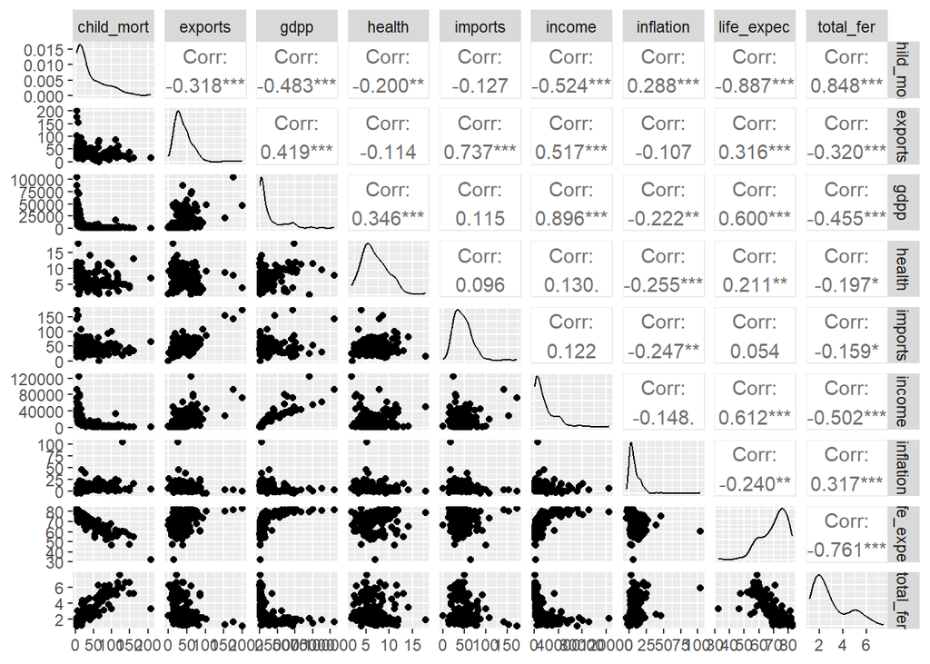

```r
ggpairs(data, columns = c("child_mort", "exports", "gdpp", "health", "imports", "income", "inflation", "life_expec", "total_fer"))
```

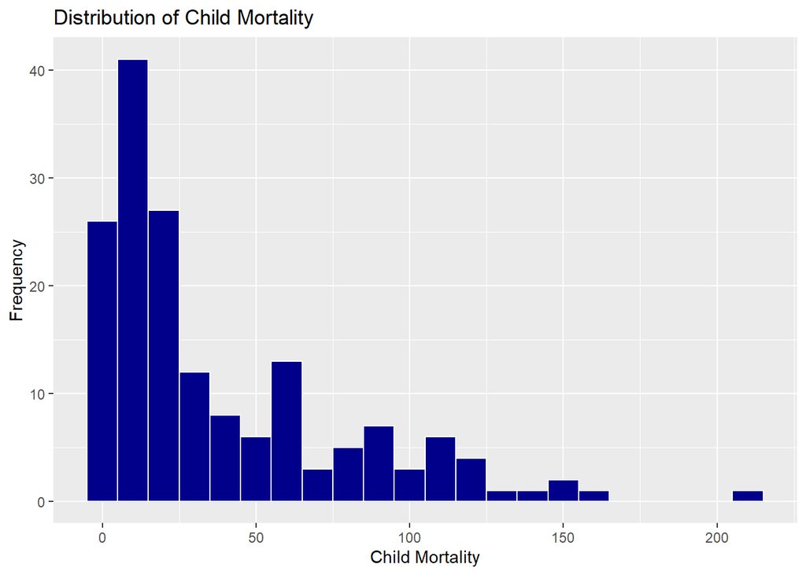

```r
# Plot distribution of Child Mortality
ggplot(data, aes(x = child_mort)) +
  geom_histogram(binwidth = 10, fill = "darkblue", color = "white") +
  labs(x = "Child Mortality", y = "Frequency", title = "Distribution of Child Mortality")
```

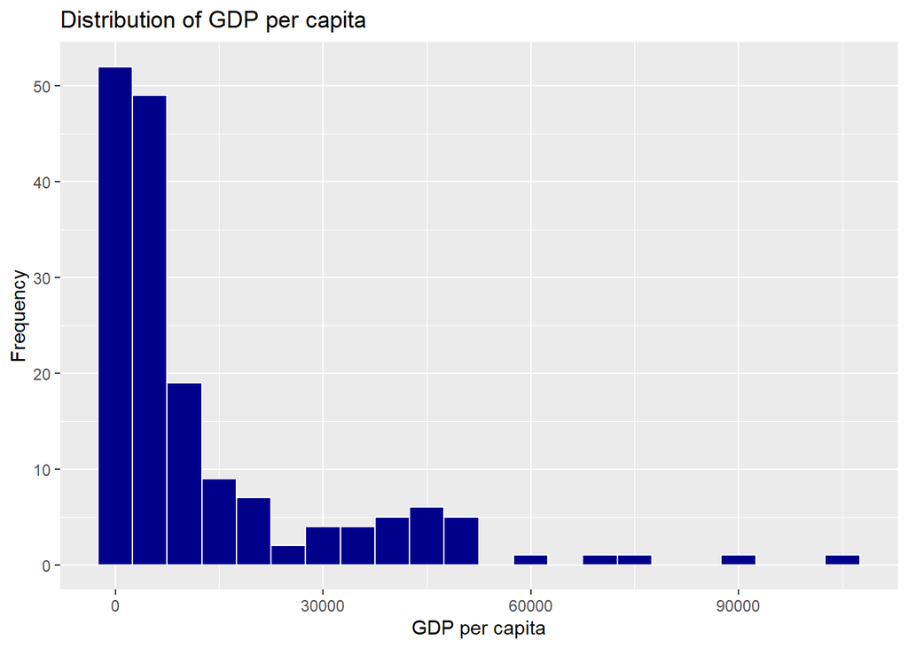

```r
# Plot distribution of GDP per capita
ggplot(data, aes(x = gdpp)) +
  geom_histogram(binwidth = 5000, fill = "darkblue", color = "white") +
  labs(x = "GDP per capita", y = "Frequency", title = "Distribution of GDP per capita")
```

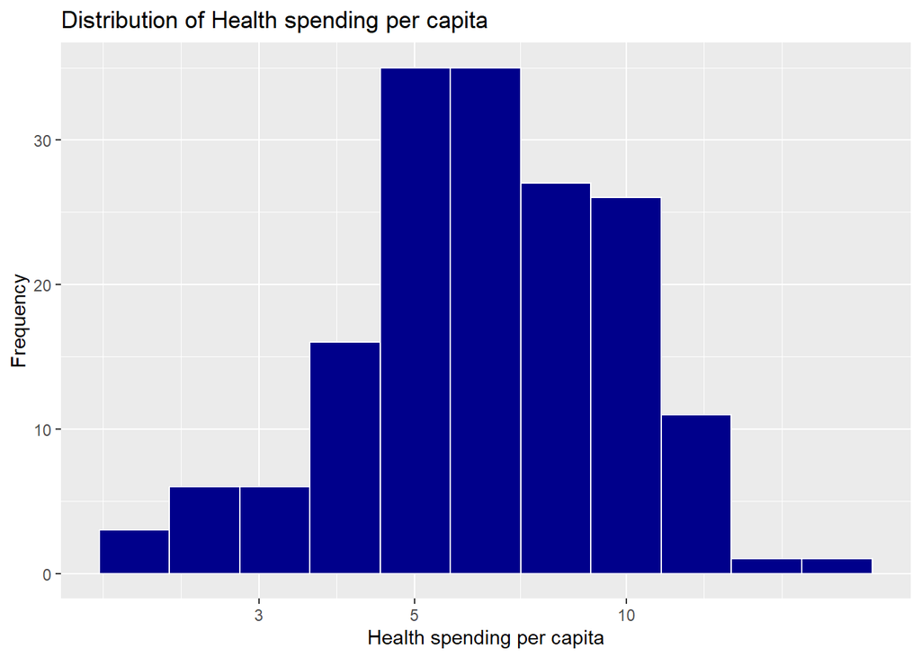

```r
# Plot distribution of Health spending per capita
ggplot(data, aes(x = health)) +
  geom_histogram(binwidth = 0.1, fill = "darkblue", color = "white") +
  scale_x_log10() +
  labs(x = "Health spending per capita", y = "Frequency", title = "Distribution of Health spending per capita")
```

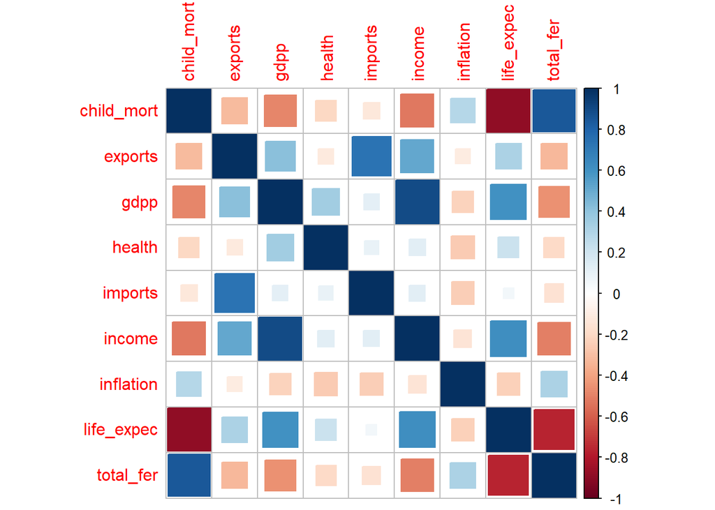

```r
# Create a correlation matrix of the columns in your data table
cor_mat <- cor(data[, c("child_mort", "exports", "gdpp", "health", "imports", "income", "inflation", "life_expec", "total_fer")])

# Create the correlation plot using corrplot
corrplot(cor_mat, method="square")
```

```r
# Compute correlation matrix
# Print correlation matrix with 2 decimal places
cor_matrix <- cor(data[, c("child_mort", "exports", "gdpp", "health", "imports", "income", "inflation", "life_expec", "total_fer")])
print(round(cor_matrix, 2))
```

```
##            child_mort exports  gdpp health imports income inflation life_expec
## child_mort       1.00   -0.32 -0.48  -0.20   -0.13  -0.52      0.29      -0.89
## exports         -0.32    1.00  0.42  -0.11    0.74   0.52     -0.11       0.32
## gdpp            -0.48    0.42  1.00   0.35    0.12   0.90     -0.22       0.60
## health          -0.20   -0.11  0.35   1.00    0.10   0.13     -0.26       0.21
## imports         -0.13    0.74  0.12   0.10    1.00   0.12     -0.25       0.05
## income          -0.52    0.52  0.90   0.13    0.12   1.00     -0.15       0.61
## inflation        0.29   -0.11 -0.22  -0.26   -0.25  -0.15      1.00      -0.24
## life_expec      -0.89    0.32  0.60   0.21    0.05   0.61     -0.24       1.00
## total_fer        0.85   -0.32 -0.45  -0.20   -0.16  -0.50      0.32      -0.76
##            total_fer
## child_mort      0.85
## exports        -0.32
## gdpp           -0.45
## health         -0.20
## imports        -0.16
## income         -0.50
## inflation       0.32
## life_expec     -0.76
## total_fer       1.00
```

Our group initially selected child mortality, as higher levels of this variable are a good indicator of a long term country well-being and development.

“Children born in poorer countries are also more likely to die before reaching age 5. Children born in low-income countries, where the 2021 U5MR was 67 deaths per 1,000 live births, were 14 times more likely to die before reaching age 5 than children born in high-income countries, where the 2021 U5MR was just 5 deaths per 1,000 live births. At the country level, U5MRs in 2021 ranged from 2 deaths per 1,000 live births to 115 deaths per 1,000 live births, 67 times higher than in the lowest mortality country.” ( https://data.unicef.org/)

There are also ample situational factors that lead to higher levels of infant mortality related to the pregnant woman’s education, quality of industrial enviroment and political infrastructure. (https://www.ncbi.nlm.nih.gov/pmc/articles/PMC4508882/)

The fundamental argument is that obstacles related to the environment and society hinder the availability of essential healthcare resources, leading to a rise in infant mortality. Developing countries account for 99% of infant deaths, with 86% of these deaths attributed to factors such as infections, preterm births, delivery complications, and perinatal asphyxia and birth injuries. (https://www.sciencedirect.com/science/article/abs/pii/B9780123708779000840?via%3Dihub)

Based on the correlation scores, the variables with the highest values with the target variable (child_mort = Child mortality rate) are:

income (-0.52) gdpp (-0.48) life_expec (-0.89) total_fer (0.85)

Considering the given variables and their correlations with child mortality, the following combination could be interesting to explore :

Child mortality, Income, Life expectancy: This mix focuses on the relationship between child mortality and two key socioeconomic indicators - income and life expectancy. It could allow to analyze how economic factors and overall health conditions influence child mortality rates.

As the first stem we should handle the missing values of the data. We will proceed to count the missing data so we can get a sense of how big is the problem.

```r
# Count missing values in each variable

child_mort_missing <- sum(is.na(data$child_mort))
income_missing <- sum(is.na(data$income))
life_expec_missing <- sum(is.na(data$life_expec))


child_mort_missing
```

```
## [1] 0
```

```r
income_missing
```

```
## [1] 0
```

```r
life_expec_missing
```

```
## [1] 0
```

The values indicate that there are no missing data, we dont need to worry about having to do data imputation or deleting incomplete rows.

As explained in class, the effectiveness of k-means clustering is greatly influenced by the scaling of variables, making it essential to have variables with commensurate units. Additionally, if the distribution of the variables being analyzed is skewed, k-means clustering may yield unfavorable outcomes.

We will proceed to test the skewness of the selected variables.

```r
# Load the necessary package
library(moments)

# Calculate skewness for each variable
skewness(data$child_mort)
```

```
## [1] 1.43771
```

```r
skewness(data$income)
```

```
## [1] 2.211386
```

```r
skewness(data$life_expec)
```

```
## [1] -0.9622522
```

After calculating the skewness scores for each variable, the results are as follows:

Child mortality: Skewness score = 1.43771 Income: Skewness score = 2.211386 Life expectancy: Skewness score = -0.9622522

These skewness scores provide insights into the distributional characteristics of the variables. A positive skewness score indicates a longer tail on the right side of the distribution, while a negative skewness score indicates a longer tail on the left side. A skewness score close to zero suggests a relatively symmetric distribution.

Based on the scores obtained, income appears to have a relatively high positive skewness, while life expectancy has a negative skewness. Child mortality has a skewness scores close to 1, indicating a slightly right-skewed distribution.

Considering these scores, it may be advisable to explore potential data transformations for variables with notable skewness to attain a more symmetric distribution prior to undertaking the k-means clustering analysis.

```r
summary(data$child_mort)
```

```
##    Min. 1st Qu.  Median    Mean 3rd Qu.    Max.
##    2.60    8.25   19.30   38.27   62.10  208.00
```

```r
summary(data$income)
```

```
##    Min. 1st Qu.  Median    Mean 3rd Qu.    Max.
##     609    3355    9960   17145   22800  125000
```

```r
summary(data$life_expec)
```

```
##    Min. 1st Qu.  Median    Mean 3rd Qu.    Max.
##   32.10   65.30   73.10   70.56   76.80   82.80
```

```r
# Logarithmic transformation
data$log_income <- log(data$income)
data$log_child_mort <- log(data$child_mort)

# Square root transformation
data$sqrt_income <- sqrt(data$income)
data$sqrt_child_mort <- sqrt(data$child_mort)

# Calculate skewness after transformations
log_income <- skewness(data$log_income)
sqrt_income <- skewness(data$sqrt_income)
log_child_mort <- skewness(data$log_child_mort)
sqrt_child_mort <- skewness(data$sqrt_child_mort)

# Print the skewness values
cat("Logarithmic transformation - Income: ", log_income, "\n")
```

```
## Logarithmic transformation - Income:  -0.2340644
```

```r
cat("Square root transformation - Income: ", sqrt_income, "\n")
```

```
## Square root transformation - Income:  0.8489575
```

```r
cat("Logarithmic transformation - Child mortality: ", log_child_mort, "\n")
```

```
## Logarithmic transformation - Child mortality:  -0.01783166
```

```r
cat("Square root transformation - Child mortality: ", sqrt_child_mort, "\n")
```

```
## Square root transformation - Child mortality:  0.7136011
```

Comparing the skewness values, we can see that the logarithmic transformation has reduced the skewness for both the “Income” and “Child mortality” variables, resulting in values closer to zero. The logarithmic transformation has shown to be more effective in reducing skewness in this case.

Now we find ourselves in a situation where life expectancy has high skewness values when compared to the new values or the rest of the selected variables, we will perform also similar operations so we can later experiment with all the combinations possible.

```r
# Logarithmic transformation
transformed_life_expec_log <- log(data$life_expec)
log_life_expec <- skewness(transformed_life_expec_log)

# Square root transformation
transformed_life_expec_sqrt <- sqrt(data$life_expec)
sqrt_life_expec <- skewness(transformed_life_expec_sqrt)

# Print the skewness values
cat("Logarithmic transformation - Life expectancy: ", log_life_expec, "\n")
```

```
## Logarithmic transformation - Life expectancy:  -1.628076
```

```r
cat("Square root transformation - Life expectancy: ", sqrt_life_expec, "\n")
```

```
## Square root transformation - Life expectancy:  -1.243957
```

Based on the obtained skewness values (-1.628076 for the logarithmic transformation and -1.243957 for the square root transformation), it appears that both transformations have resulted in further negative skewness for the “life_expec” variable. This means that the transformed variable is even more skewed than the original variable.

```r
# Choosing the variables for segmentation
X <- data[, c("log_child_mort", "log_income", "life_expec")]

# Scatterplot to visualize the relationships between variables
scatterplot <- ggplot(X, aes(x = child_mort, y = income)) +
  geom_point()  # Customize the scatterplot as needed

# Evaluating appropriate number of clusters using the elbow method
elbow_plot <- factoextra::fviz_nbclust(
  x = X,
  method = "wss",
  FUNcluster = kmeans
) + geom_vline(xintercept = 4, linetype = 2)  # Adjust the number of clusters as needed

# K-means clustering
model_seg <- stats::kmeans(
  x = X,
  centers = 3,
  iter.max = 10,
  nstart = 10
)

# Model summary
str(model_seg)
```

```
## List of 9
##  $ cluster     : int [1:167] 3 2 2 3 2 2 2 2 2 1 ...
##  $ centers     : num [1:3, 1:3] 3.58 2.14 4.53 8.56 10.02 ...
##   ..- attr(*, "dimnames")=List of 2
##   .. ..$ : chr [1:3] "1" "2" "3"
##   .. ..$ : chr [1:3] "log_child_mort" "log_income" "life_expec"
##  $ totss       : num 13603
##  $ withinss    : num [1:3] 405 777 1122
##  $ tot.withinss: num 2304
##  $ betweenss   : num 11299
##  $ size        : int [1:3] 47 85 35
##  $ iter        : int 2
##  $ ifault      : int 0
##  - attr(*, "class")= chr "kmeans"
```

```r
model_seg
```

```
## K-means clustering with 3 clusters of sizes 47, 85, 35
##
## Cluster means:
##   log_child_mort log_income life_expec
## 1       3.581393   8.556409   68.21277
## 2       2.143709  10.022781   77.51059
## 3       4.527314   7.662415   56.81143
##
## Clustering vector:
##   [1] 3 2 2 3 2 2 2 2 2 1 2 2 1 2 1 2 1 3 1 1 2 3 2 2 2 3 3 1 3 2 1 3 3 2 2 2 1
##  [38] 3 3 2 3 2 2 2 2 2 2 1 2 3 3 2 1 2 2 1 1 1 2 3 2 1 1 3 3 1 3 2 2 1 1 2 1 2
##  [75] 2 2 2 2 2 1 1 3 2 1 1 2 2 3 3 2 2 2 2 3 3 2 2 3 2 1 2 1 1 1 2 2 3 1 3 1 2
## [112] 2 3 3 2 2 1 2 2 2 1 2 2 2 2 1 1 1 2 1 2 2 3 2 2 2 3 3 2 2 2 1 1 1 2 2 1 3
## [149] 2 1 3 1 2 2 1 3 1 2 2 2 2 1 1 2 2 1 3
##
## Within cluster sum of squares by cluster:
## [1]  405.1379  776.6618 1121.8098
##  (between_SS / total_SS =  83.1 %)
##
## Available components:
##
## [1] "cluster"      "centers"      "totss"        "withinss"     "tot.withinss"
## [6] "betweenss"    "size"         "iter"         "ifault"
```

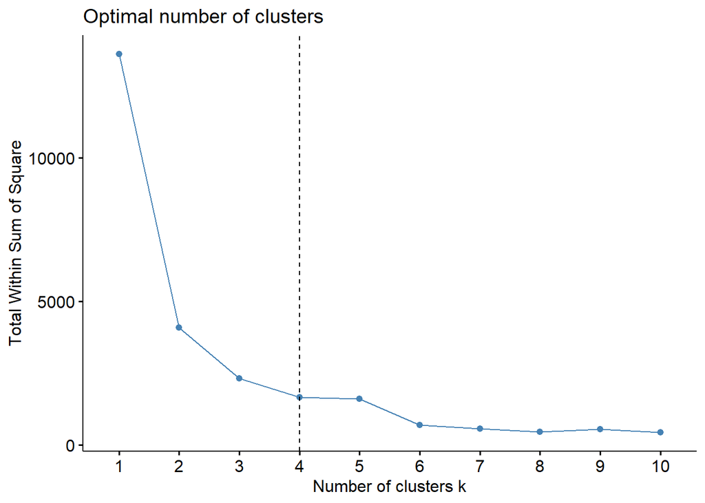

```r
# Segmentation visualization
segmentation_plot <- factoextra::fviz_cluster(
  object = model_seg,
  data = X,
  geom = "point",
  stand = FALSE,
  show.clust.cent = TRUE
) + theme_light()

# Print the plots
print(elbow_plot)
```

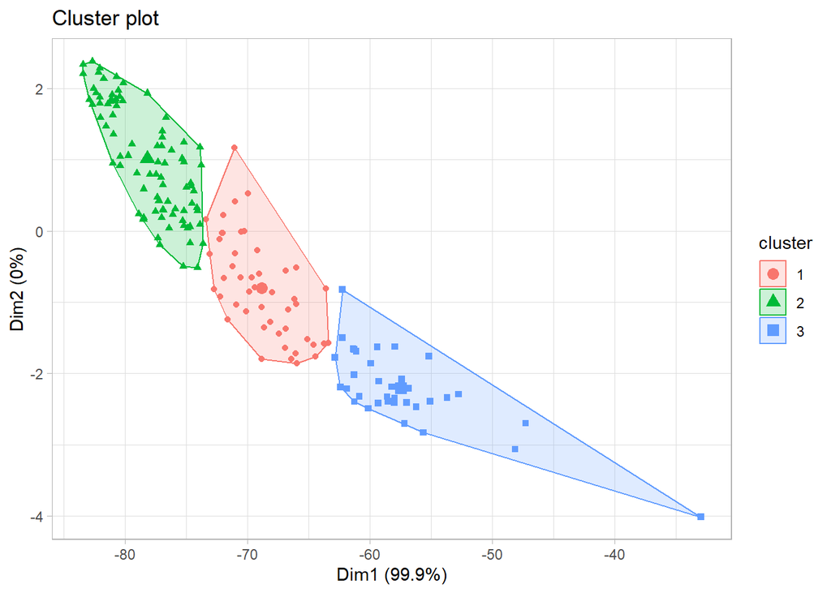

```r
print(segmentation_plot)
```

The cluster plot displays the data points based on their assigned clusters, with the x-axis and y-axis on the plot representing dimensions resulting from the reduction technique used in the clustering algorithm. Each data point will be represented by a dot, with the color of the dot indicating the assigned cluster, and the cluster center will be represented by a larger point/symbol.

```r
library(pander)
library(stringr)

# Order the data by cluster
ordered_data <- data[order(model_seg$cluster), ]
ordered_data$cluster <- as.factor(model_seg$cluster)

# Print the country lists ordered by cluster
cluster_summary <- ordered_data %>%
  group_by(cluster) %>%
  summarise(Countries = paste(country, collapse = ", "))

# Convert cluster_summary to a character matrix
cluster_summary_matrix <- as.matrix(cluster_summary)

# Set column names
colnames(cluster_summary_matrix) <- c("Cluster", "Countries")

# Display the table using pander
pander(cluster_summary_matrix, split.table = Inf)
```

[output not shown]